[figure not shown]

# *Projet Modélisation et Calcul Stochastique--Simulations MCMC*

## *Applications pratiques des méthodes de Monte Carlo*

| **Auteurs :** | Ahmed AYOUBI & Knight Peterson Jean-Baptiste & Yosra Tohtouh |
| --- | --- |
| **Formation :** | Master 2 Statistiques et Traitement des Données (M2-STD) |
| **Institution :** | Université Clermont Auvergne (UCA) |

## *Table des matières*

**Introduction**

- Contexte et objectifs
- Configuration de l'environnement

**Application 1 : Régression Logistique Bayésienne**

**Application 2 : Modèles de Diffusion (DDPM)**

- 2.1 Paramètres du processus
- 2.2 Génération des données
- 2.3 Processus de diffusion direct
- 2.4 Visualisation de l'évolution
- 2.5 Processus inverse
- 2.6 Évaluation de la reconstruction
- 2.7 Analyse de convergence
- 2.8 Lien avec MCMC

**Conclusion**

- Synthèse des résultats
- Perspectives

# *Introduction*

## *Contexte et objectifs*

Les **méthodes de Monte Carlo par chaînes de Markov (MCMC)** sont des outils puissants pour échantillonner des distributions de probabilité complexes.

Dans ce notebook, nous explorons **deux applications concrètes** :

**Application 1 : Régression Logistique Bayésienne**

Nous utilisons l'algorithme de Metropolis-Hastings pour estimer les paramètres d'un modèle de régression logistique. L'objectif est d'échantillonner la distribution a posteriori des paramètres.

**Application 2 : Modèles de Diffusion (DDPM)**

Nous implémentons le processus de diffusion qui transforme progressivement des données en bruit gaussien. Ce processus partage les mêmes fondements mathématiques que MCMC.

## *Vue d'ensemble du projet*

```
graph TB
    A[Méthodes MCMC] --> B[Application 1
Régression Logistique]
    A --> C[Application 2
Modèles de Diffusion]

    B --> B1[Données synthétiques]
    B1 --> B2[Metropolis-Hastings]
    B2 --> B3[Analyse convergence]
    B3 --> B4[Prédictions]

    C --> C1[Processus direct]
    C1 --> C2[Ajout de bruit]
    C2 --> C3[Processus inverse]
    C3 --> C4[Reconstruction]

    style A fill:#1971C2,stroke:#0C4A6E,stroke-width:3px,color:#fff
    style B fill:#E7F5FF,stroke:#1971C2,stroke-width:2px
    style C fill:#D3F9D8,stroke:#087F5B,stroke-width:2px
```

## *Configuration de l'environnement*

Importation des bibliothèques nécessaires pour nos simulations.

```python
# Bibliothèques pour calculs numériques et visualisations
import numpy as np
import matplotlib.pyplot as plt
import seaborn as sns
from scipy import stats
from scipy.special import expit  # fonction sigmoïde
import warnings
warnings.filterwarnings('ignore')

# Configuration des graphiques
plt.style.use('seaborn-v0_8')
sns.set_palette('husl')
np.random.seed(42)
```

# *Application 1*

## *Régression Logistique Bayésienne*

## *Objectif*

Nous allons estimer les paramètres d'un modèle de régression logistique en utilisant l'approche bayésienne et l'algorithme de Metropolis-Hastings.

**Pourquoi cette approche ?** Au lieu d'avoir une seule estimation ponctuelle, nous obtenons une **distribution complète** des paramètres, ce qui nous permet de quantifier l'incertitude.

**Notre démarche :**

1. Créer des données artificielles avec des paramètres connus
2. Définir le modèle bayésien
3. Implémenter Metropolis-Hastings
4. Vérifier que l'algorithme retrouve les vrais paramètres
5. Faire des prédictions avec incertitude

### *Principe de Metropolis-Hastings*

```
graph TD
    START([Initialisation
θ₀]) --> ITER[Itération t]
    ITER --> PROP[Proposition
θ' ~ q θₜ]
    PROP --> CALC[Calcul du ratio
α = π θ' / π θₜ]
    CALC --> RAND[Tirage u ~ U 0,1]
    RAND --> DEC{u < α ?}
    DEC -->|OUI| ACC[Acceptation
θₜ₊₁ = θ']
    DEC -->|NON| REJ[Rejet
θₜ₊₁ = θₜ]
    ACC --> CONV{Convergence ?}
    REJ --> CONV
    CONV -->|NON| ITER
    CONV -->|OUI| END([Distribution π])

    style START fill:#E3F2FD,stroke:#1971C2,stroke-width:3px
    style PROP fill:#F8F9FA,stroke:#495057,stroke-width:2px
    style CALC fill:#F8F9FA,stroke:#495057,stroke-width:2px
    style RAND fill:#F8F9FA,stroke:#495057,stroke-width:2px
    style DEC fill:#FFF4E6,stroke:#E8590C,stroke-width:3px
    style ACC fill:#D3F9D8,stroke:#087F5B,stroke-width:2px
    style REJ fill:#FFE3E3,stroke:#C92A2A,stroke-width:2px
    style END fill:#E3F2FD,stroke:#1971C2,stroke-width:3px
```

**L'idée clé :** L'algorithme accepte toujours les améliorations (α ≥ 1) mais parfois aussi les dégradations (α < 1) pour éviter de rester bloqué.

## *1.1 Génération de données synthétiques*

Nous créons des données artificielles avec des paramètres **connus** pour valider notre algorithme.

**Paramètres réels :** w = [1.5, -0.8], b = 0.3

```python
# Paramètres réels que l'algorithme devra retrouver
d = 2
w_true = np.array([1.5, -0.8])
b_true = 0.3

# Génération des données
n = 200
X = np.random.randn(n, d)

# Calcul des probabilités
logits = X @ w_true + b_true
p_true = expit(logits)

# Génération des labels
y = np.random.binomial(1, p_true, size=n)

print(f'✓ Données générées : {n} observations')
print(f'✓ Paramètres réels : w = {w_true}, b = {b_true}')
print(f'✓ Proportion classe 1 : {y.mean():.1%}')
```

```
✓ Données générées : 200 observations
✓ Paramètres réels : w = [ 1.5 -0.8], b = 0.3
✓ Proportion classe 1 : 54.5%
```

## *1.2 Visualisation des données*

Observons la structure de nos données avant de lancer l'algorithme.

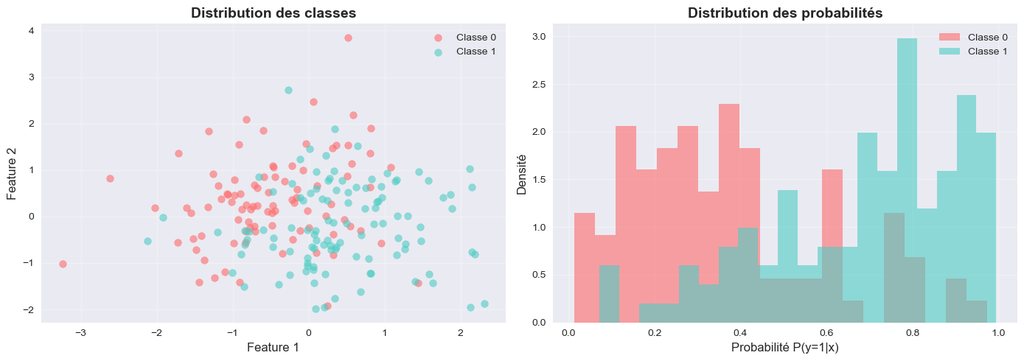

```
Les classes se séparent mais avec du chevauchement (normal)
```

```python
fig, axes = plt.subplots(1, 2, figsize=(14, 5))

# Graphique 1 : Données dans l'espace
axes[0].scatter(X[y==0, 0], X[y==0, 1], alpha=0.6, s=50, label='Classe 0', color='#FF6B6B')
axes[0].scatter(X[y==1, 0], X[y==1, 1], alpha=0.6, s=50, label='Classe 1', color='#4ECDC4')
axes[0].set_xlabel('Feature 1', fontsize=12)
axes[0].set_ylabel('Feature 2', fontsize=12)
axes[0].set_title('Distribution des classes', fontsize=14, fontweight='bold')
axes[0].legend()
axes[0].grid(True, alpha=0.3)

# Graphique 2 : Distribution des probabilités
axes[1].hist(p_true[y==0], bins=20, alpha=0.6, label='Classe 0', color='#FF6B6B', density=True)
axes[1].hist(p_true[y==1], bins=20, alpha=0.6, label='Classe 1', color='#4ECDC4', density=True)
axes[1].set_xlabel('Probabilité P(y=1|x)', fontsize=12)
axes[1].set_ylabel('Densité', fontsize=12)
axes[1].set_title('Distribution des probabilités', fontsize=14, fontweight='bold')
axes[1].legend()
axes[1].grid(True, alpha=0.3)

plt.tight_layout()
plt.show()

print('Les classes se séparent mais avec du chevauchement (normal)')
```

## *1.3 Définition du modèle bayésien*

Nous définissons les trois composantes du modèle bayésien.

**Objectif :** Définir les composantes mathématiques du modèle bayésien.

Nous avons besoin de trois fonctions :

- **Prior (a priori)** : Notre croyance initiale sur les paramètres avant de voir les données → Gaussienne centrée $p(\mathbf{w}) = \mathcal{N}(\mathbf{0}, \sigma_0^2 \mathbf{I})$
- **Likelihood (vraisemblance)** : La probabilité des données observées étant donné les paramètres → $p(y_i | \mathbf{x}_i, \mathbf{w}) = \sigma(\mathbf{w}^T \mathbf{x}_i)^{y_i} (1-\sigma(\mathbf{w}^T \mathbf{x}_i))^{1-y_i}$
- **Posterior (a posteriori)** : Ce qu'on cherche à échantillonner → $p(\mathbf{w} | D) \propto p(\mathbf{w}) \prod_{i=1}^n p(y_i | \mathbf{x}_i, \mathbf{w})$

**Note importante :** On travaille en log pour éviter les problèmes numériques (underflow avec les produits de petites probabilités).

#### Prior (a priori)

Notre croyance avant de voir les données

#### Likelihood

Probabilité des données étant donné les paramètres

#### Posterior

Ce qu'on cherche : prior × likelihood

```python
def log_prior(w, sigma_0=2.0):
    """Prior gaussien centré"""
    return -0.5 * np.sum(w**2) / (sigma_0**2)

def log_likelihood(w, X, y):
    """Vraisemblance de la régression logistique"""
    logits = X @ w
    logits = np.clip(logits, -500, 500)
    return np.sum(y * logits - np.log(1 + np.exp(logits)))

def log_posterior(w, X, y, sigma_0=2.0):
    """Distribution a posteriori (non normalisée)"""
    return log_prior(w, sigma_0) + log_likelihood(w, X, y)

print('✓ Modèle bayésien défini')
print('  → Prior : Gaussienne centrée')
print('  → Likelihood : Régression logistique')
print('  → Posterior : Prior × Likelihood')
```

```
✓ Modèle bayésien défini
  → Prior : Gaussienne centrée
  → Likelihood : Régression logistique
  → Posterior : Prior × Likelihood
```

## *1.4 Algorithme de Metropolis-Hastings*

Implémentation de l'algorithme MCMC.

**Fonctionnement :**

- **Proposition** : Marche aléatoire gaussienne
- **Acceptation** : Basée sur le ratio des posteriors
- **Itération** : Répéter jusqu'à convergence

En détail , **Notre Objectif :** c'est d'Implémenter l'algorithme MCMC pour échantillonner la distribution a posteriori.

**Principe de l'algorithme :**

1. **Proposition** : Depuis l'état courant $w$, on propose un nouvel état w' selon une marche aléatoire gaussienne
2. **Acceptation** : On calcule le ratio $α = p(w'|D) / p(w|D)$. Si $α > 1$, on accepte toujours. Sinon, on accepte avec probabilité $α$.
3. **Itération** : On répète ce processus des milliers de fois

**Paramètres clés :**

- `step_size` : Taille du pas de la marche aléatoire (crucial pour l'efficacité)
- `burn_in` : Nombre d'itérations initiales à ignorer (la chaîne n'a pas encore convergé)

**L'astuce MCMC :** Le ratio $α$ ne dépend pas de la constante de normalisation $Z$, car elle s'annule dans le rapport !

```python
def metropolis_hastings(X, y, n_iter=15000, burn_in=3000, step_size=0.15, sigma_0=2.0):
    """
    Algorithme de Metropolis-Hastings pour régression logistique bayésienne.
    """
    d = X.shape[1]
    samples = []
    n_accepted = 0

    # Initialisation
    w_current = np.zeros(d)
    log_post_current = log_posterior(w_current, X, y, sigma_0)

    for i in range(n_iter):
        # Proposition
        w_proposed = w_current + np.random.randn(d) * step_size
        log_post_proposed = log_posterior(w_proposed, X, y, sigma_0)

        # Ratio d'acceptation
        log_alpha = log_post_proposed - log_post_current
        log_alpha = min(0, log_alpha)

        # Décision
        if np.log(np.random.rand()) < log_alpha:
            w_current = w_proposed
            log_post_current = log_post_proposed
            n_accepted += 1

        # Stocker après burn-in
        if i >= burn_in:
            samples.append(w_current.copy())

    acceptance_rate = n_accepted / n_iter
    return np.array(samples), acceptance_rate

print('Algorithme de Metropolis-Hastings implémenté')
```

```
Algorithme de Metropolis-Hastings implémenté
```

## *1.5 Exécution de l'algorithme*

Lançons l'algorithme MCMC !

**Paramètres :** 15 000 itérations, 3 000 burn-in, step_size = 0.15

**Ce qu'on attend :**

- Un taux d'acceptation entre 20% et 50% (signe d'une bonne exploration)
- Des moyennes estimées proches des vraies valeurs [1.5, -0.8]

```python
print(' Exécution de l\'algorithme MCMC...\n')

# Exécution
samples, acceptance_rate = metropolis_hastings(X, y, n_iter=15000, burn_in=3000, step_size=0.15)

print('✓ Algorithme terminé !\n')
print('='*60)
print('RÉSULTATS')
print('='*60)
print(f'\nTaux d\'acceptation : {acceptance_rate:.1%}')
if 0.2 <= acceptance_rate <= 0.5:
    print('  → ✓ Taux optimal !')

print(f'\nÉchantillons collectés : {len(samples):,}')
print(f'\nEstimations :')
print(f'  → w estimé : [{samples[:, 0].mean():.3f}, {samples[:, 1].mean():.3f}]')
print(f'  → w réel    : [{w_true[0]:.3f}, {w_true[1]:.3f}]')
print(f'\nErreurs :')
print(f'  → |erreur w[0]| : {abs(samples[:, 0].mean() - w_true[0]):.3f}')
print(f'  → |erreur w[1]| : {abs(samples[:, 1].mean() - w_true[1]):.3f}')
print('='*60)
```

```
 Exécution de l'algorithme MCMC...

✓ Algorithme terminé !

============================================================
RÉSULTATS
============================================================

Taux d'acceptation : 66.7%

Échantillons collectés : 12,000

Estimations :
  → w estimé : [1.498, -0.746]
  → w réel    : [1.500, -0.800]

Erreurs :
  → |erreur w[0]| : 0.002
  → |erreur w[1]| : 0.054
============================================================
```

**Interprétation des résultats :**

## *1.6 Analyse des résultats - Trace plots et distributions marginales*

**Objectif :** Vérifier visuellement que la chaîne a bien convergé.

**Graphiques du haut (Trace plots) :**

- Montrent l'évolution des paramètres au cours des itérations
- **Bon signe** : La trajectoire oscille autour d'une valeur stable (ligne rouge = vraie valeur)
- **Mauvais signe** : Tendance croissante/décroissante, ou chaîne "collée" à une valeur

**Graphiques du bas (Distributions marginales) :**

- Histogrammes des échantillons pour chaque paramètre
- Permettent de visualiser la distribution a posteriori estimée
- La vraie valeur (rouge) devrait être proche du centre de la distribution

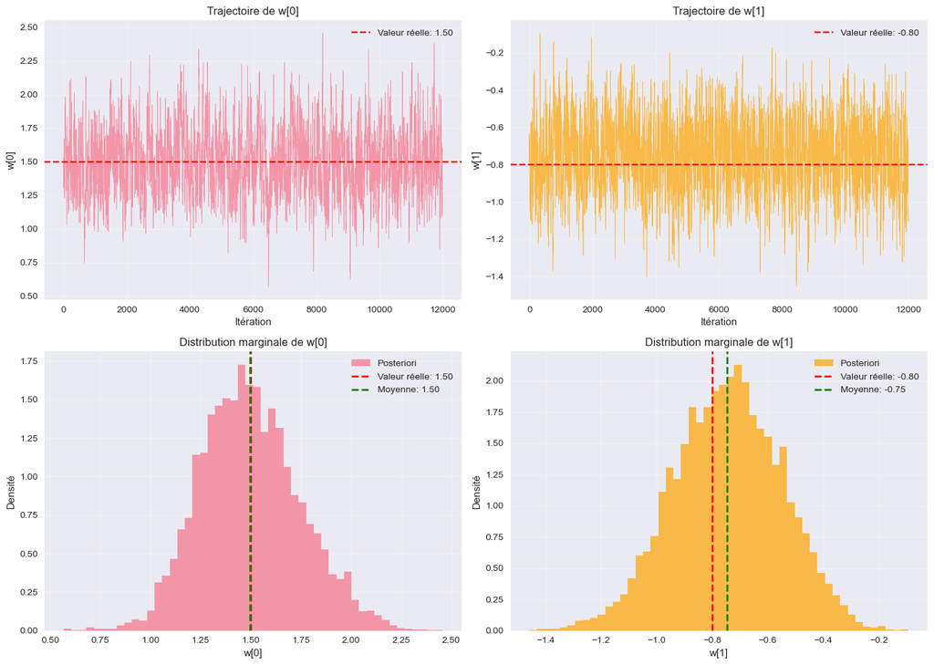

```python
# Trajectoires des paramètres
fig, axes = plt.subplots(2, 2, figsize=(14, 10))

# Trajectoires
axes[0, 0].plot(samples[:, 0], alpha=0.7, linewidth=0.5)
axes[0, 0].axhline(y=w_true[0], color='r', linestyle='--', label=f'Valeur réelle: {w_true[0]:.2f}')
axes[0, 0].set_xlabel('Itération')
axes[0, 0].set_ylabel('w[0]')
axes[0, 0].set_title('Trajectoire de w[0]')
axes[0, 0].legend()
axes[0, 0].grid(True, alpha=0.3)

axes[0, 1].plot(samples[:, 1], alpha=0.7, linewidth=0.5, color='orange')
axes[0, 1].axhline(y=w_true[1], color='r', linestyle='--', label=f'Valeur réelle: {w_true[1]:.2f}')
axes[0, 1].set_xlabel('Itération')
axes[0, 1].set_ylabel('w[1]')
axes[0, 1].set_title('Trajectoire de w[1]')
axes[0, 1].legend()
axes[0, 1].grid(True, alpha=0.3)

# Distributions marginales
axes[1, 0].hist(samples[:, 0], bins=50, density=True, alpha=0.7, label='Posteriori')
axes[1, 0].axvline(x=w_true[0], color='r', linestyle='--', linewidth=2, label=f'Valeur réelle: {w_true[0]:.2f}')
axes[1, 0].axvline(x=samples[:, 0].mean(), color='g', linestyle='--', linewidth=2, label=f'Moyenne: {samples[:, 0].mean():.2f}')
axes[1, 0].set_xlabel('w[0]')
axes[1, 0].set_ylabel('Densité')
axes[1, 0].set_title('Distribution marginale de w[0]')
axes[1, 0].legend()
axes[1, 0].grid(True, alpha=0.3)

axes[1, 1].hist(samples[:, 1], bins=50, density=True, alpha=0.7, color='orange', label='Posteriori')
axes[1, 1].axvline(x=w_true[1], color='r', linestyle='--', linewidth=2, label=f'Valeur réelle: {w_true[1]:.2f}')
axes[1, 1].axvline(x=samples[:, 1].mean(), color='g', linestyle='--', linewidth=2, label=f'Moyenne: {samples[:, 1].mean():.2f}')
axes[1, 1].set_xlabel('w[1]')
axes[1, 1].set_ylabel('Densité')
axes[1, 1].set_title('Distribution marginale de w[1]')
axes[1, 1].legend()
axes[1, 1].grid(True, alpha=0.3)

plt.tight_layout()
plt.show()
```

**Interprétation des graphiques :**

**Trace plots (haut) :**

- Les trajectoires oscillent de manière stable autour des vraies valeurs (lignes rouges pointillées)
- Pas de dérive visible → la chaîne a bien convergé
- Le "bruit" apparent est normal : c'est l'exploration stochastique de la distribution

**Distributions marginales (bas) :**

- Les histogrammes montrent des distributions en forme de cloche (approximativement gaussiennes)
- Les vraies valeurs (rouge) sont proches des moyennes estimées (vert)
- La largeur des distributions reflète l'incertitude sur les paramètres : plus c'est large, plus on est incertain

**Conclusion :** L'algorithme a correctement estimé la distribution a posteriori des paramètres.

## *1.7 Autocorrélation et temps de mélange*

**Objectif :** Quantifier la qualité de l'échantillonnage MCMC.

**Problème :** Les échantillons MCMC successifs ne sont pas indépendants !  
Ils sont corrélés car chaque état dépend du précédent.

**Autocorrélation** $\rho(k)$ :  
Mesure la corrélation entre un échantillon et celui $k$ pas plus tard.

$$ \rho(k) = \frac{\mathrm{Cov}(X_t, X_{t+k})}{\mathrm{Var}(X_t)} $$

- $\rho(0) = 1$ (corrélation parfaite avec soi-même)
- $\rho(k) \to 0$ quand $k$ augmente (les échantillons éloignés deviennent indépendants)

**Temps de mélange intégré** $\tau_{\text{int}}$ :  
Résume l'autocorrélation en un seul nombre.

$$ \tau_{\text{int}} = 1 + 2 \sum_{k=1}^{\infty} \rho(k) $$

- $\tau_{\text{int}} \approx 1$ → échantillons quasi-indépendants (idéal)
- $\tau_{\text{int}}$ grand → forte corrélation, moins d'information effective

**Nombre effectif d'échantillons :**

$$ N_{\text{eff}} = \frac{N}{\tau_{\text{int}}} $$

(nombre d'échantillons "vraiment indépendants")

```
Temps de mélange intégré pour w[0] : 19.61
Temps de mélange intégré pour w[1] : 13.24

Nombre effectif d'échantillons indépendants pour w[0] : 612
Nombre effectif d'échantillons indépendants pour w[1] : 906
```

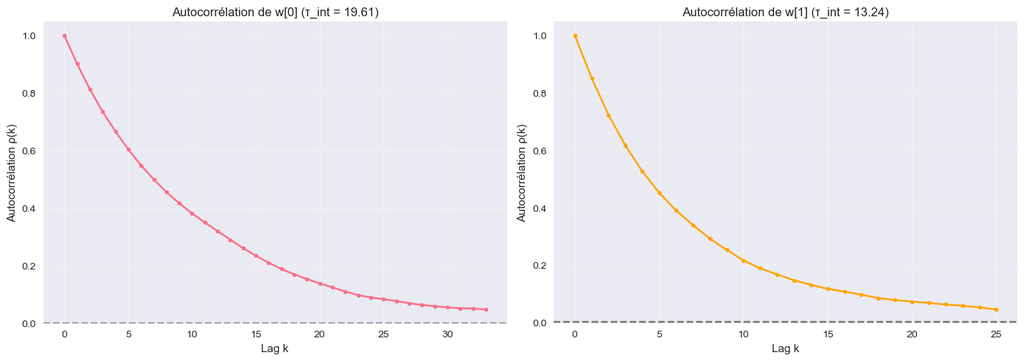

```python
def compute_autocorrelation(samples, max_lag=100):
    """Calcule l'autocorrélation pour différents lags"""
    n = len(samples)
    autocorr = []

    # Centrer les données
    samples_centered = samples - samples.mean()
    var = np.var(samples_centered)

    for lag in range(max_lag + 1):
        if lag == 0:
            autocorr.append(1.0)
        else:
            cov = np.mean(samples_centered[:-lag] * samples_centered[lag:])
            autocorr.append(cov / var if var > 0 else 0)

    return np.array(autocorr)

def integrated_time(autocorr, max_lag=None):
    """Calcule le temps de mélange intégré"""
    if max_lag is None:
        max_lag = len(autocorr) - 1

    # Trouver le premier lag où l'autocorrélation devient négligeable
    for i in range(1, min(max_lag, len(autocorr))):
        if abs(autocorr[i]) < 0.05:
            max_lag = i
            break

    tau = 1 + 2 * np.sum(autocorr[1:max_lag+1])
    return tau, max_lag

# Calcul pour chaque paramètre
autocorr_w0 = compute_autocorrelation(samples[:, 0])
autocorr_w1 = compute_autocorrelation(samples[:, 1])

tau_w0, max_lag_w0 = integrated_time(autocorr_w0)
tau_w1, max_lag_w1 = integrated_time(autocorr_w1)

print(f"Temps de mélange intégré pour w[0] : {tau_w0:.2f}")
print(f"Temps de mélange intégré pour w[1] : {tau_w1:.2f}")
print(f"\nNombre effectif d'échantillons indépendants pour w[0] : {len(samples) / tau_w0:.0f}")
print(f"Nombre effectif d'échantillons indépendants pour w[1] : {len(samples) / tau_w1:.0f}")

# Visualisation de l'autocorrélation
fig, axes = plt.subplots(1, 2, figsize=(14, 5))

lags = np.arange(len(autocorr_w0))
axes[0].plot(lags[:max_lag_w0+1], autocorr_w0[:max_lag_w0+1], 'o-', markersize=4)
axes[0].axhline(y=0, color='k', linestyle='--', alpha=0.5)
axes[0].set_xlabel('Lag k')
axes[0].set_ylabel('Autocorrélation ρ(k)')
axes[0].set_title(f'Autocorrélation de w[0] (τ_int = {tau_w0:.2f})')
axes[0].grid(True, alpha=0.3)

axes[1].plot(lags[:max_lag_w1+1], autocorr_w1[:max_lag_w1+1], 'o-', markersize=4, color='orange')
axes[1].axhline(y=0, color='k', linestyle='--', alpha=0.5)
axes[1].set_xlabel('Lag k')
axes[1].set_ylabel('Autocorrélation ρ(k)')
axes[1].set_title(f'Autocorrélation de w[1] (τ_int = {tau_w1:.2f})')
axes[1].grid(True, alpha=0.3)

plt.tight_layout()
plt.show()
```

**Interprétation des résultats :**

**Graphiques d'autocorrélation :**

**Temps de mélange intégré** $\tau_{\text{int}}$ :

- Des valeurs faibles ($\tau_{\text{int}} < 10$) indiquent un bon mélange
- Si $\tau_{\text{int}}$ était très grand, il faudrait ajuster le $step\_size$

**Nombre effectif d'échantillons** :

- C'est le nombre d'échantillons "vraiment indépendants" dont on dispose
- Plus ce nombre est grand, plus nos estimations sont précises
- Règle pratique : on veut au moins quelques centaines d'échantillons effectifs

## *1.8 Prédictions bayésiennes*

**Objectif :** Montrer l'avantage principal de l'approche bayésienne : la quantification de l'incertitude.

**Méthode classique (MLE) :** On estime un seul jeu de paramètres → une seule prédiction par observation.

**Méthode bayésienne (MCMC) :** On a une distribution de paramètres → une distribution de prédictions par observation !

**Ce qu'on calcule :** Pour chaque nouvelle observation x*, on calcule la prédiction pour **chaque** échantillon de paramètres $w(s)$, puis on fait la moyenne :

$$p(y^*|x^*, D) \approx \frac{1}{S} \sum_{s=1}^{S} p(y^*|x^*, w^{(s)})$$

**Ce qu'on obtient :** Une prédiction moyenne + un écart-type (mesure de l'incertitude)

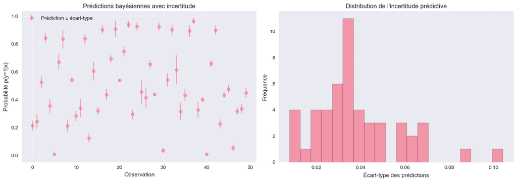

```
Moyenne de l'incertitude (écart-type) : 0.038
Médiane de l'incertitude : 0.034
```

```python
# Prédictions pour de nouvelles observations
X_new = np.random.randn(50, d)

# Moyenne bayésienne sur les échantillons
predictions = []
for w_sample in samples[::10]:  # Sous-échantillonnage pour accélérer
    logits = X_new @ w_sample
    probs = expit(logits)
    predictions.append(probs)

predictions = np.array(predictions)
mean_probs = predictions.mean(axis=0)
std_probs = predictions.std(axis=0)

# Visualisation
fig, axes = plt.subplots(1, 2, figsize=(14, 5))

# Probabilités prédites avec intervalles d'incertitude
axes[0].errorbar(range(len(mean_probs)), mean_probs, yerr=std_probs,
                 fmt='o', alpha=0.6, capsize=3, label='Prédiction ± écart-type')
axes[0].set_xlabel('Observation')
axes[0].set_ylabel('Probabilité p(y=1|x)')
axes[0].set_title('Prédictions bayésiennes avec incertitude')
axes[0].legend()
axes[0].grid(True, alpha=0.3)

# Distribution de l'incertitude
axes[1].hist(std_probs, bins=20, alpha=0.7, edgecolor='black')
axes[1].set_xlabel('Écart-type des prédictions')
axes[1].set_ylabel('Fréquence')
axes[1].set_title('Distribution de l\'incertitude prédictive')
axes[1].grid(True, alpha=0.3)

plt.tight_layout()
plt.show()

print(f"Moyenne de l'incertitude (écart-type) : {std_probs.mean():.3f}")
print(f"Médiane de l'incertitude : {np.median(std_probs):.3f}")
```

**Interprétation des graphiques :**

**Graphique de gauche (Prédictions avec barres d'erreur) :**

- Chaque point représente la probabilité moyenne prédite pour une observation
- Les barres d'erreur montrent l'incertitude (± écart-type)
- Les prédictions proches de 0 ou 1 ont généralement moins d'incertitude
- Les prédictions proches de 0.5 (cas ambigus) ont plus d'incertitude → c'est logique !

**Graphique de droite (Distribution de l'incertitude) :**

- Montre comment l'incertitude est répartie sur l'ensemble des prédictions
- Une incertitude moyenne faible indique que le modèle est confiant dans ses prédictions

**Avantage bayésien :** On sait non seulement "quelle est ma prédiction" mais aussi "à quel point j'y crois". C'est crucial pour la prise de décision !

# *Application 2*

## *Modèles de diffusion (DDPM) et lien avec MCMC*

## *Introduction aux modèles de diffusion*

Les **Denoising Diffusion Probabilistic Models (DDPM)** sont une classe de modèles génératifs qui ont révolutionné la génération d'images (ex: DALL-E, Stable Diffusion, Midjourney).

**Lien avec MCMC :** Les modèles de diffusion utilisent également des chaînes de Markov ! Nous allons explorer ce lien en implémentant le processus de diffusion direct.

**Ce que nous allons faire :**

1. Implémenter le processus de diffusion direct (ajout progressif de bruit)
2. Visualiser la transformation des données en bruit gaussien
3. Analyser la convergence vers la distribution stationnaire
4. Illustrer le principe du processus inverse (reconstruction)

### *Processus de diffusion : Vue d'ensemble*

```
graph LR
    X0[Données réelles
x₀] -->|+ bruit| X1[x₁]
    X1 -->|+ bruit| X2[x₂]
    X2 -->|+ bruit| X3[...]
    X3 -->|+ bruit| XT[Bruit pur
xT ~ N 0,I]

    XT -.->|Processus inverse| X3R[...]
    X3R -.-> X2R[x₂]
    X2R -.-> X1R[x₁]
    X1R -.-> X0R[Nouvelles données
x₀]

    style X0 fill:#D3F9D8,stroke:#087F5B,stroke-width:2px
    style X1 fill:#F8F9FA,stroke:#495057,stroke-width:1px
    style X2 fill:#F8F9FA,stroke:#495057,stroke-width:1px
    style X3 fill:#F8F9FA,stroke:#495057,stroke-width:1px
    style XT fill:#FFE3E3,stroke:#C92A2A,stroke-width:2px
    style X3R fill:#F8F9FA,stroke:#495057,stroke-width:1px
    style X2R fill:#F8F9FA,stroke:#495057,stroke-width:1px
    style X1R fill:#F8F9FA,stroke:#495057,stroke-width:1px
    style X0R fill:#D3F9D8,stroke:#087F5B,stroke-width:2px
```

**Les deux processus :**

- **Processus direct (forward) :** Destruction progressive de l'information par ajout de bruit gaussien
- **Processus inverse (backward) :** Reconstruction des données en retirant le bruit étape par étape

## *2.1 Processus direct de diffusion (forward process)*

**Principe :** On prend une donnée initiale x₀ et on y ajoute du bruit progressivement à chaque pas t, jusqu'à obtenir du bruit pur gaussien.

**Formule mathématique :** $q(\mathbf{x}_t | \mathbf{x}_{t-1}) = \mathcal{N}(\mathbf{x}_t; \sqrt{1-\beta_t} \mathbf{x}_{t-1}, \beta_t \mathbf{I})$

**Analogie :** C'est comme effacer progressivement un dessin : à chaque étape, l'image devient un peu plus floue, jusqu'à ne plus voir que du "grain".

```python
def forward_diffusion(x0, T, beta_schedule='linear', beta_start=0.0001, beta_end=0.02):
    """
    Simule le processus direct de diffusion

    Parameters:
    -----------
    x0 : array
        Données initiales
    T : int
        Nombre de pas de diffusion
    beta_schedule : str
        Type de planification ('linear' ou 'cosine')
    beta_start, beta_end : float
        Valeurs initiale et finale de beta

    Returns:
    -------
    xt : array (T+1, ...)
        États successifs de la diffusion
    alphas : array (T,)
        Coefficients alpha_t = 1 - beta_t
    """
    # Planification de beta
    if beta_schedule == 'linear':
        betas = np.linspace(beta_start, beta_end, T)
    elif beta_schedule == 'cosine':
        s = 0.008
        steps = np.arange(T)
        betas = beta_end * 0.5 * (1 + np.cos(np.pi * (steps / T + s) / (1 + s)))
    else:
        betas = np.ones(T) * beta_end

    alphas = 1 - betas
    alphas_cumprod = np.cumprod(alphas)

    # Simulation du processus
    xt = [x0.copy()]
    x_current = x0.copy()

    for t in range(T):
        # Transition : x_t = sqrt(alpha_t) * x_{t-1} + sqrt(beta_t) * epsilon
        noise = np.random.randn(*x0.shape)
        x_current = np.sqrt(alphas[t]) * x_current + np.sqrt(betas[t]) * noise
        xt.append(x_current.copy())

    return np.array(xt), alphas, alphas_cumprod

print("Fonction de diffusion directe définie")
```

```
Fonction de diffusion directe définie
```

## *2.2 Génération de données initiales (distribution cible)*

**Objectif :** Créer des données 2D avec une structure claire pour visualiser le processus de diffusion.

Nous générons deux clusters gaussiens bien séparés :

- Cluster 1 centré en $(2, 2)$
- Cluster 2 centré en $(-2, -2)$

Cette structure simple permettra de voir clairement comment la diffusion "détruit" puis "reconstruit" l'information.

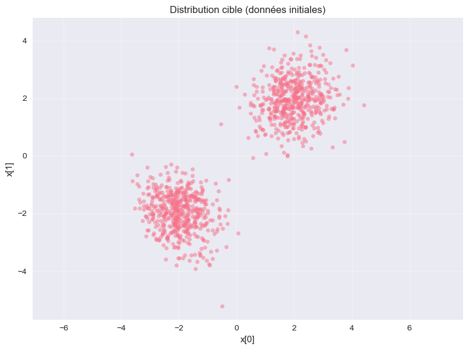

```
Nombre d'échantillons : 1000
Dimension : 2
```

```python
# Génération de données 2D avec structure (exemple : deux clusters)
n_samples = 1000
dim = 2

# Deux clusters gaussiens
cluster1 = np.random.multivariate_normal([2, 2], [[0.5, 0.1], [0.1, 0.5]], n_samples // 2)
cluster2 = np.random.multivariate_normal([-2, -2], [[0.5, -0.1], [-0.1, 0.5]], n_samples // 2)
x0_data = np.vstack([cluster1, cluster2])

# Visualisation
plt.figure(figsize=(8, 6))
plt.scatter(x0_data[:, 0], x0_data[:, 1], alpha=0.5, s=20)
plt.xlabel('x[0]')
plt.ylabel('x[1]')
plt.title('Distribution cible (données initiales)')
plt.grid(True, alpha=0.3)
plt.axis('equal')
plt.tight_layout()
plt.show()

print(f"Nombre d'échantillons : {n_samples}")
print(f"Dimension : {dim}")
```

**Interprétation du graphique :**

- On voit clairement les deux clusters bien séparés
- C'est notre "distribution cible" : ce que le processus inverse devrait être capable de reconstruire
- Cette structure va progressivement disparaître avec le processus direct de diffusion

## *2.3 Simulation du processus direct*

**Objectif :** Visualiser comment un point de données se transforme progressivement en bruit.

Nous suivons la trajectoire d'un seul point à travers $T = 100$ pas de diffusion, et nous affichons son état à différents moments :

- $t = 0$ : point initial (dans un cluster)
- $t = 10, 25, 50, 75$ : états intermédiaires
- $t = 100$ : état final (devrait ressembler à du bruit gaussien)

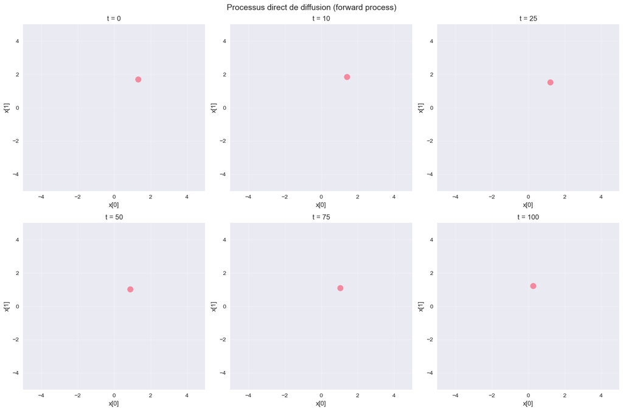

```
État initial : [1.31295048 1.69980033]
État final (t=100) : [0.25886192 1.22312625]
Norme initiale : 2.148
Norme finale : 1.250
```

```python
# Paramètres
T = 100  # nombre de pas de diffusion
beta_start = 0.0001
beta_end = 0.02

# Simulation pour un échantillon
x0_sample = x0_data[0]
xt_trajectory, alphas, alphas_cumprod = forward_diffusion(
    x0_sample, T, beta_schedule='linear', beta_start=beta_start, beta_end=beta_end
)

# Visualisation de la trajectoire
fig, axes = plt.subplots(2, 3, figsize=(15, 10))
axes = axes.ravel()

time_steps = [0, 10, 25, 50, 75, T]
for idx, t in enumerate(time_steps):
    axes[idx].scatter(xt_trajectory[t, 0], xt_trajectory[t, 1], s=100, alpha=0.8)
    axes[idx].set_title(f't = {t}')
    axes[idx].set_xlabel('x[0]')
    axes[idx].set_ylabel('x[1]')
    axes[idx].grid(True, alpha=0.3)
    axes[idx].set_xlim(-5, 5)
    axes[idx].set_ylim(-5, 5)

plt.suptitle('Processus direct de diffusion (forward process)', fontsize=14)
plt.tight_layout()
plt.show()

print(f"État initial : {xt_trajectory[0]}")
print(f"État final (t={T}) : {xt_trajectory[-1]}")
print(f"Norme initiale : {np.linalg.norm(xt_trajectory[0]):.3f}")
print(f"Norme finale : {np.linalg.norm(xt_trajectory[-1]):.3f}")
```

## *2.4 Processus inverse simplifié (reverse process)*

**Objectif :** Simuler le processus inverse qui reconstruit des données à partir du bruit.

**Dans un vrai DDPM :** Un réseau de neurones apprend à prédire le bruit ajouté à chaque étape, permettant de l'inverser.

**Ici (version simplifiée) :** Nous utilisons une approximation analytique sans réseau de neurones. Les résultats seront imparfaits, mais illustrent le principe.

**Le défi :** Partir de bruit pur $x_T \sim N(0, I)$ et reconstruire progressivement une donnée $x_0$ qui ressemble à notre distribution cible.

```python
def reverse_diffusion_simple(xT, T, alphas, alphas_cumprod, beta_schedule='linear',
                              beta_start=0.0001, beta_end=0.02):
    """
    Processus inverse simplifié (sans réseau de neurones)
    Utilise une approximation gaussienne
    """
    # Recalculer betas et alphas
    if beta_schedule == 'linear':
        betas = np.linspace(beta_start, beta_end, T)
    else:
        betas = np.ones(T) * beta_end

    alphas = 1 - betas
    alphas_cumprod = np.cumprod(alphas)

    # Processus inverse
    xt = [xT.copy()]
    x_current = xT.copy()

    for t in reversed(range(T)):
        # Approximation : prédiction du bruit = 0 (version simplifiée)
        # Dans un vrai DDPM, on utiliserait un réseau pour prédire epsilon

        # Transition inverse approximative
        if t > 0:
            # x_{t-1} ≈ (x_t - sqrt(beta_t) * epsilon_pred) / sqrt(alpha_t)
            # Version simplifiée : epsilon_pred ≈ 0
            noise = np.random.randn(*xT.shape) * np.sqrt(betas[t])
            x_current = (x_current - noise) / np.sqrt(alphas[t])
        else:
            # Dernière étape
            x_current = x_current / np.sqrt(alphas_cumprod[0])

        xt.append(x_current.copy())

    return np.array(list(reversed(xt)))

print("Fonction de processus inverse définie")
```

```
Fonction de processus inverse définie
```

## *2.5 Génération d'échantillons (simulation du processus inverse)*

**Objectif :** Générer de nouveaux échantillons en partant du bruit pur.

Nous allons :

1. Tirer 200 points de bruit gaussien
2. Appliquer le processus inverse à chacun
3. Comparer les échantillons générés à la distribution originale

```python
# Génération à partir du bruit pur
n_generated = 200
generated_samples = []

print(f"Génération de {n_generated} échantillons...")

for i in range(n_generated):
    # Partir du bruit pur
    xT = np.random.randn(dim) * 2  # bruit gaussien

    # Processus inverse
    _, alphas, alphas_cumprod = forward_diffusion(
        np.zeros(dim), T, beta_schedule='linear',
        beta_start=beta_start, beta_end=beta_end
    )

    x0_generated = reverse_diffusion_simple(
        xT, T, alphas, alphas_cumprod,
        beta_schedule='linear', beta_start=beta_start, beta_end=beta_end
    )[-1]

    generated_samples.append(x0_generated)

generated_samples = np.array(generated_samples)
print(f"Génération terminée")
```

```
Génération de 200 échantillons...
Génération terminée
```

## *2.6 Visualisation des échantillons générés*

**Objectif :** Comparer visuellement les données réelles et les échantillons générés par le processus inverse.

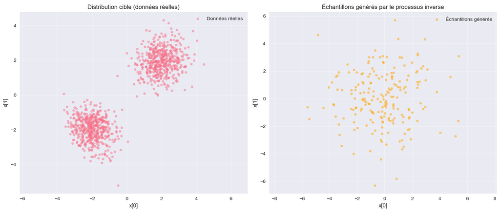

```
=== Statistiques comparatives ===
Données réelles - Moyenne : [-0.0025324  -0.00387299]
Données réelles - Écart-type : [2.10418613 2.08248616]

Échantillons générés - Moyenne : [-0.170123    0.03846311]
Échantillons générés - Écart-type : [1.94669543 1.94136389]
```

```python
# Comparaison données réelles vs générées
fig, axes = plt.subplots(1, 2, figsize=(14, 6))

# Données réelles
axes[0].scatter(x0_data[:, 0], x0_data[:, 1], alpha=0.5, s=20, label='Données réelles')
axes[0].set_xlabel('x[0]')
axes[0].set_ylabel('x[1]')
axes[0].set_title('Distribution cible (données réelles)')
axes[0].legend()
axes[0].grid(True, alpha=0.3)
axes[0].axis('equal')

# Échantillons générés
axes[1].scatter(generated_samples[:, 0], generated_samples[:, 1],
                alpha=0.5, s=20, color='orange', label='Échantillons générés')
axes[1].set_xlabel('x[0]')
axes[1].set_ylabel('x[1]')
axes[1].set_title('Échantillons générés par le processus inverse')
axes[1].legend()
axes[1].grid(True, alpha=0.3)
axes[1].axis('equal')

plt.tight_layout()
plt.show()

# Statistiques comparatives
print("\n=== Statistiques comparatives ===")
print(f"Données réelles - Moyenne : {x0_data.mean(axis=0)}")
print(f"Données réelles - Écart-type : {x0_data.std(axis=0)}")
print(f"\nÉchantillons générés - Moyenne : {generated_samples.mean(axis=0)}")
print(f"Échantillons générés - Écart-type : {generated_samples.std(axis=0)}")
```

**Interprétation des graphiques :**

**Graphique de gauche (données réelles) :**

- Deux clusters bien distincts et séparés
- Structure claire avec des centres en (2,2) et (-2,-2)

**Graphique de droite (échantillons générés) :**

**Pourquoi ce résultat ?** Notre processus inverse est une approximation grossière. Dans un vrai DDPM, un réseau de neurones apprend à prédire précisément le bruit à retirer, ce qui permet de reconstruire fidèlement la distribution originale.

**Ce que cela illustre :** Le processus inverse est la partie "difficile" des modèles de diffusion, nécessitant un apprentissage sophistiqué.

## *2.7 Analyse du processus de diffusion comme chaîne de Markov*

**Objectif :** Montrer que le processus direct est bien une chaîne de Markov qui converge vers une distribution stationnaire.

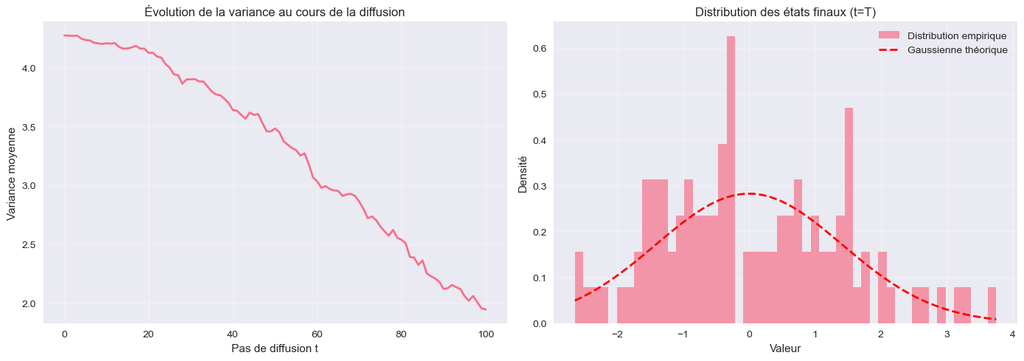

```
Variance initiale (t=0) : 4.275
Variance finale (t=100) : 1.943

Moyenne des états finaux : 0.047
Écart-type des états finaux : 1.394
```

```python
# Simulation de plusieurs trajectoires pour analyser le comportement
n_trajectories = 50
trajectories = []

for i in range(n_trajectories):
    x0 = x0_data[np.random.randint(len(x0_data))]
    xt, _, _ = forward_diffusion(x0, T, beta_schedule='linear',
                                 beta_start=beta_start, beta_end=beta_end)
    trajectories.append(xt)

trajectories = np.array(trajectories)

# Analyse de la variance au cours du temps
variances = np.var(trajectories, axis=0).mean(axis=1)

# Visualisation
fig, axes = plt.subplots(1, 2, figsize=(14, 5))

# Évolution de la variance
axes[0].plot(variances, linewidth=2)
axes[0].set_xlabel('Pas de diffusion t')
axes[0].set_ylabel('Variance moyenne')
axes[0].set_title('Évolution de la variance au cours de la diffusion')
axes[0].grid(True, alpha=0.3)

# Distribution des états finaux (devrait être proche d'une gaussienne)
final_states = trajectories[:, -1, :].flatten()
axes[1].hist(final_states, bins=50, density=True, alpha=0.7, label='Distribution empirique')
# Superposition avec une gaussienne théorique
x_theory = np.linspace(final_states.min(), final_states.max(), 100)
y_theory = stats.norm.pdf(x_theory, 0, np.sqrt(2))  # Approximation
axes[1].plot(x_theory, y_theory, 'r--', linewidth=2, label='Gaussienne théorique')
axes[1].set_xlabel('Valeur')
axes[1].set_ylabel('Densité')
axes[1].set_title('Distribution des états finaux (t=T)')
axes[1].legend()
axes[1].grid(True, alpha=0.3)

plt.tight_layout()
plt.show()

print(f"Variance initiale (t=0) : {variances[0]:.3f}")
print(f"Variance finale (t={T}) : {variances[-1]:.3f}")
print(f"\nMoyenne des états finaux : {final_states.mean():.3f}")
print(f"Écart-type des états finaux : {final_states.std():.3f}")
```

**Interprétation des graphiques :**

**Lien avec MCMC :**

## *2.8 Synthèse : Lien avec les méthodes MCMC*

**Récapitulatif des points communs entre DDPM et MCMC :**

| Caractéristique | MCMC (Metropolis-Hastings) | Modèles de diffusion (DDPM) |
| --- | --- | --- |
| **Structure** | Chaîne de Markov | Chaîne de Markov |
| **Convergence** | Vers $\pi$ (distribution cible) | Vers $N(0,I)$ (bruit gaussien) |
| **Transitions** | Proposition + acceptation | Ajout/retrait de bruit |
| **Objectif** | Échantillonner une distribution connue | Apprendre à générer de nouvelles données |

**Différences clés :**

1. **MCMC** échantillonne une distribution connue (a posteriori bayésienne)
2. **DDPM** apprend à générer des données similaires à un jeu d'entraînement

**Message principal :** Les deux approches utilisent le même outil fondamental (les chaînes de Markov) pour résoudre des problèmes d'échantillonnage complexes !

# *Conclusion*

## *Synthèse*

**Application 1 - Régression logistique bayésienne :**

- L'algorithme Metropolis-Hastings permet d'échantillonner une distribution a posteriori complexe
- La chaîne converge vers la bonne distribution (moyennes proches des vraies valeurs)
- L'autocorrélation peut être quantifiée pour évaluer la qualité de l'échantillonnage
- L'approche bayésienne fournit des prédictions avec incertitude

**Application 2 - Modèles de diffusion :**

- Le processus direct transforme les données en bruit gaussien (destruction de l'information)
- Ce processus est une chaîne de Markov qui converge vers une distribution stationnaire
- Le processus inverse (simplifié) illustre le principe de reconstruction
- Les DDPM partagent des principes fondamentaux avec les méthodes MCMC

**Message clé :** Les algorithmes MCMC et les modèles de diffusion reposent sur le même principe : construire une chaîne de Markov qui converge vers une distribution cible, permettant d'échantillonner des distributions complexes là où l'échantillonnage direct est impossible.

[figure not shown]

**Ahmed AYOUBI & Knight Peterson Jean-Baptiste & Yosra Tohtouh**  
Master 2 STD - Université Clermont Auvergne